# exercise-05

# CHALLENGE 2

# Step 1 Load data

```r
z<- "https://raw.githubusercontent.com/difiore/ada-2024-datasets/main/zombies.csv"
z<-read_csv(z, col_names = TRUE)
```

# Step 2

Calculate the population mean and standard deviation for each quantitative random variable in the dataset (height, weight, age, number of zombies killed, and years of education).

```r
library(mosaic)
mean(z$height)
```

```
## [1] 67.6301
```

```r
#summarize function dyplr to the dataframe and summarize what I want: i cand do sd for sample

#Population mean of height
height_stats <- fav_stats(z$height)

height_stats$mean
```

```
## [1] 67.6301
```

```r
#Population mean of weight
weight_stats <- fav_stats(z$weight)
weight_stats$mean
```

```
## [1] 143.9075
```

```r
#Population mean of age
age_stats <- fav_stats(z$age)
age_stats$mean
```

```
## [1] 20.04696
```

```r
#Population mean of number of zombies killed
zombies_killed_stats <- fav_stats(z$zombies_killed)
zombies_killed_stats$mean
```

```
## [1] 2.992
```

```r
#Population mean of years of education
years_of_education_stats <- fav_stats(z$years_of_education)
years_of_education_stats$mean
```

```
## [1] 2.996
```

```r
#means <- colMeans(z[, c("height", "weight", "age", "zombies_killed", "years_of_education")])
#sds <- apply(z[, c("height", "weight", "age", "zombies_killed", "years_of_education")], 2, sd)
```

# Step 3 Use {ggplot} and make boxplots of each of these variables by gender.

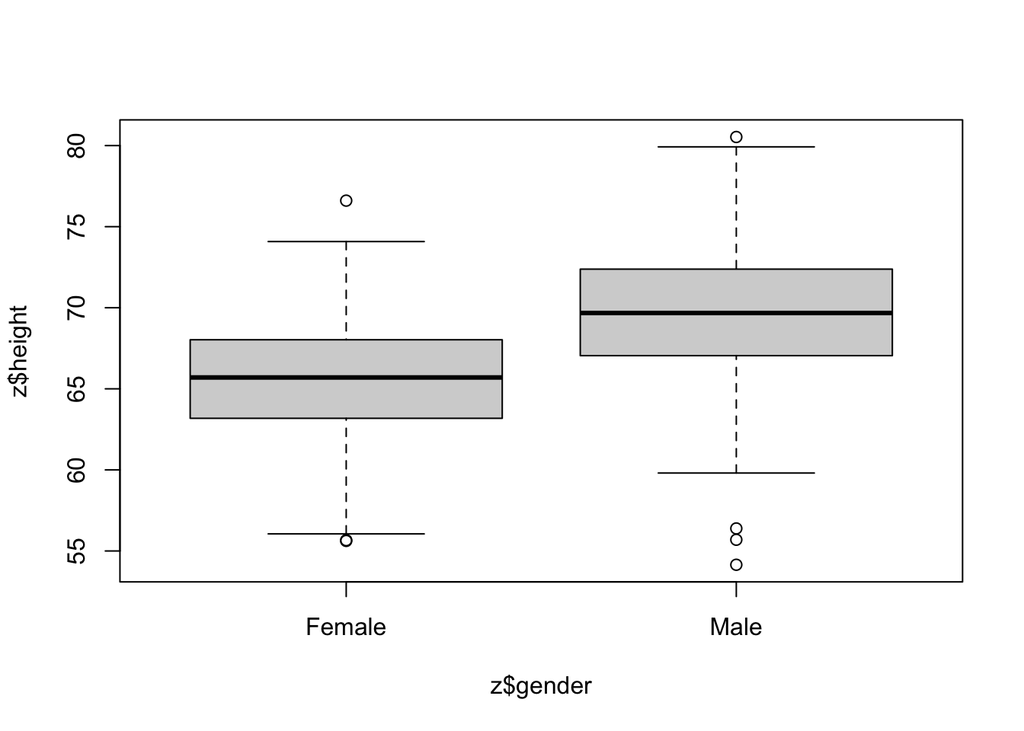

```r
boxplot(z$height ~ z$gender)
```

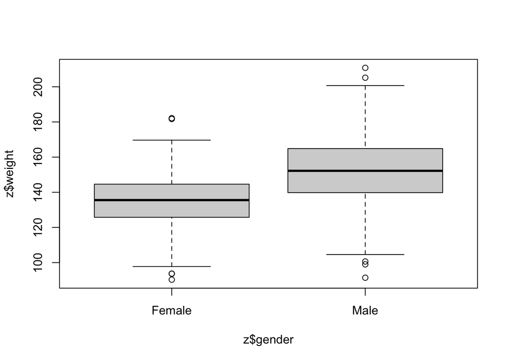

```r
 boxplot(z$weight ~ z$gender)
```

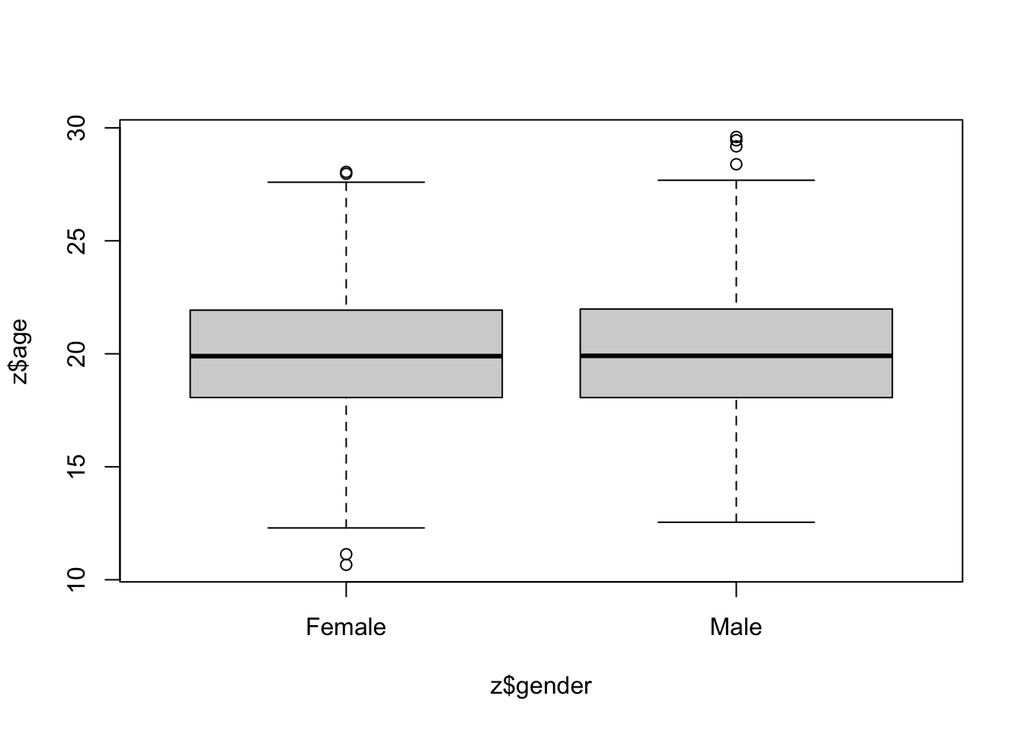

```r
 boxplot(z$age ~ z$gender)
```

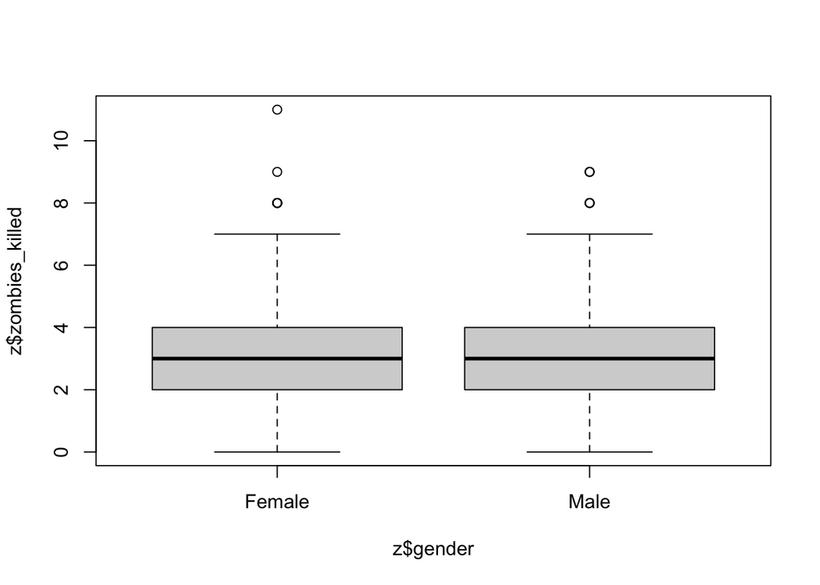

```r
  boxplot(z$zombies_killed ~ z$gender)
```

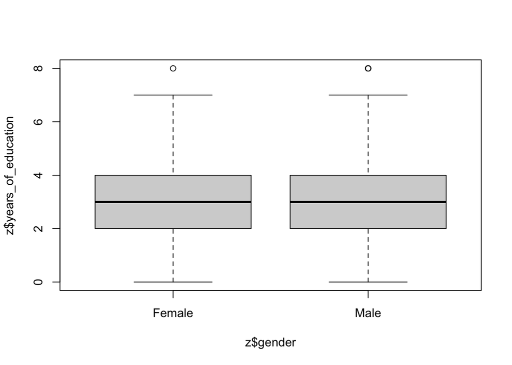

```r
   boxplot(z$years_of_education ~ z$gender)
```

# Step 4 Use {ggplot} and make scatterplots of height and weight in relation to age (i.e., use age as the variable), using different colored points for males versus females. Do these variables seem to be related? In what way?

Yes, there seems to be a positive correlation between weight and age for both females and males. The average male weight for this sample size seems higher (heavier) than the female average.

Yes, there seems to be a positive correlation between height and age for both females and males. The average male height for this sample size seems higher (taller) than the female average.

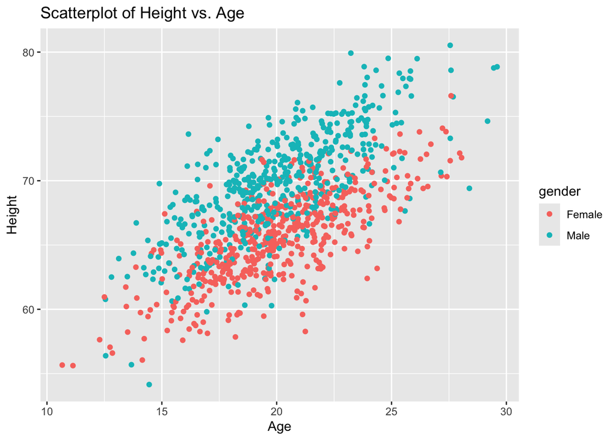

```r
ggplot(z, aes(x = age, y = height, color = gender)) +
  geom_point() +
  labs(title = "Scatterplot of Height vs. Age", x = "Age", y = "Height")
```

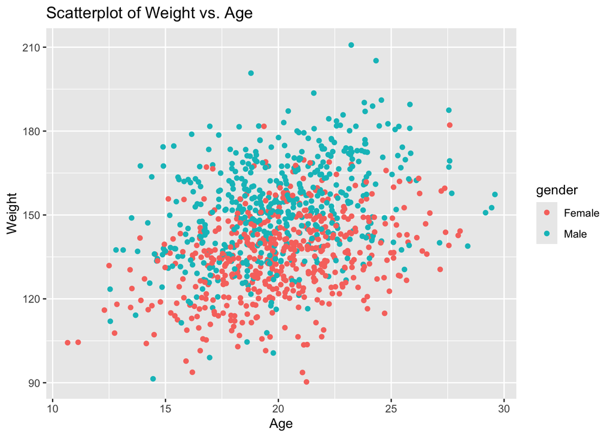

```r
# Create a scatterplot of weight vs. age, colored by gender
ggplot(z, aes(x = age, y = weight, color = gender)) +
  geom_point() +
  labs(title = "Scatterplot of Weight vs. Age", x = "Age", y = "Weight")
```

#Step 5

Using histograms and Q-Q plots, check whether each of the quantitative variables seem to be drawn from a normal distribution. Which seem to be and which do not?

##Height, weight, age, seem like a normal histogram distributions. ##Zombie kills and education are a little more off than normal. ##Same trend with the QQ plots

variables =(height, weight, age, number of zombies_killed, and years_of_education

#Here I create histograms of each quantitative variable.

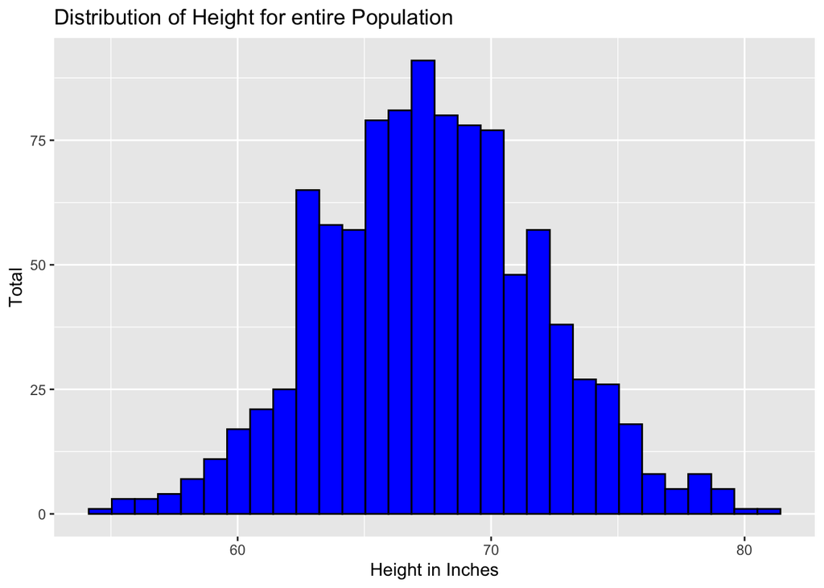

```r
HeightHist<- ggplot(z, aes(x = height)) +
  geom_histogram(color = "black", fill = "blue") +
  ggtitle("Distribution of Height for entire Population") +
  ylab("Total") +
  xlab("Height in Inches")
HeightHist
```

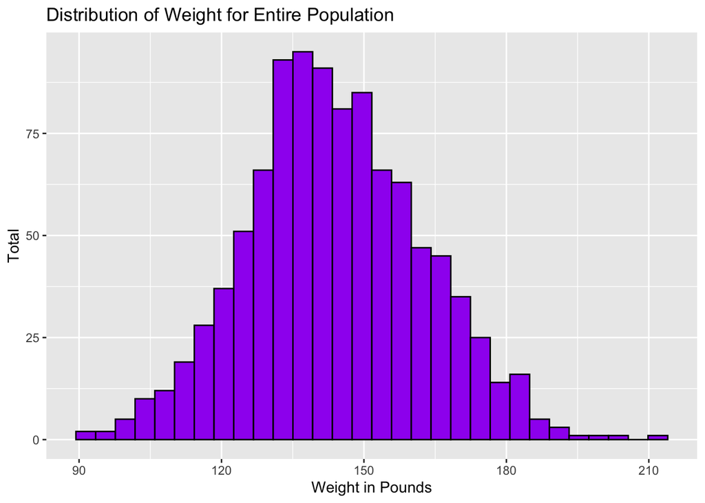

```r
WeightHist<- ggplot(z, aes(x = weight)) +
  geom_histogram(color = "black", fill = "purple") +
  ggtitle("Distribution of Weight for Entire Population") +
  ylab("Total") +
  xlab("Weight in Pounds")
WeightHist
```

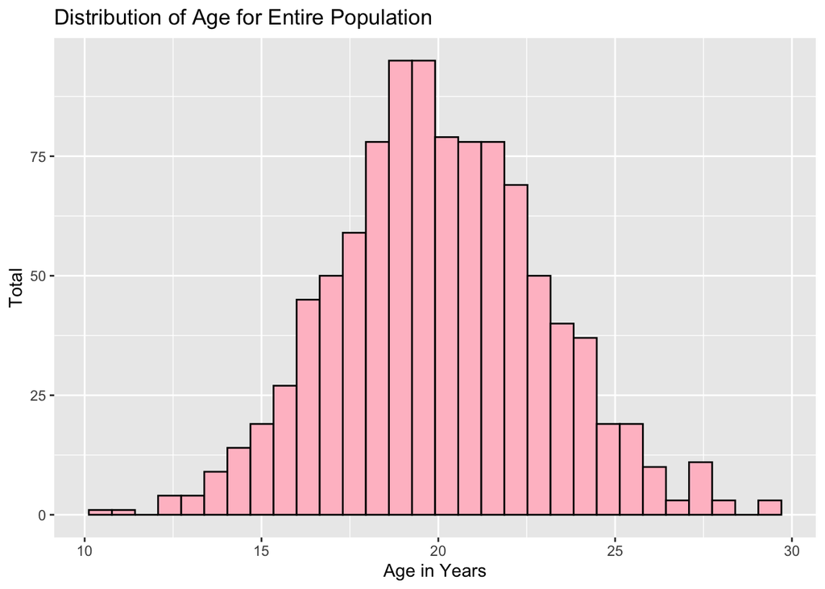

```r
AgeHist<- ggplot(z, aes(x = age)) +
  geom_histogram(color = "black", fill = "pink") +
  ggtitle("Distribution of Age for Entire Population") +
  ylab("Total") +
  xlab("Age in Years")
AgeHist
```

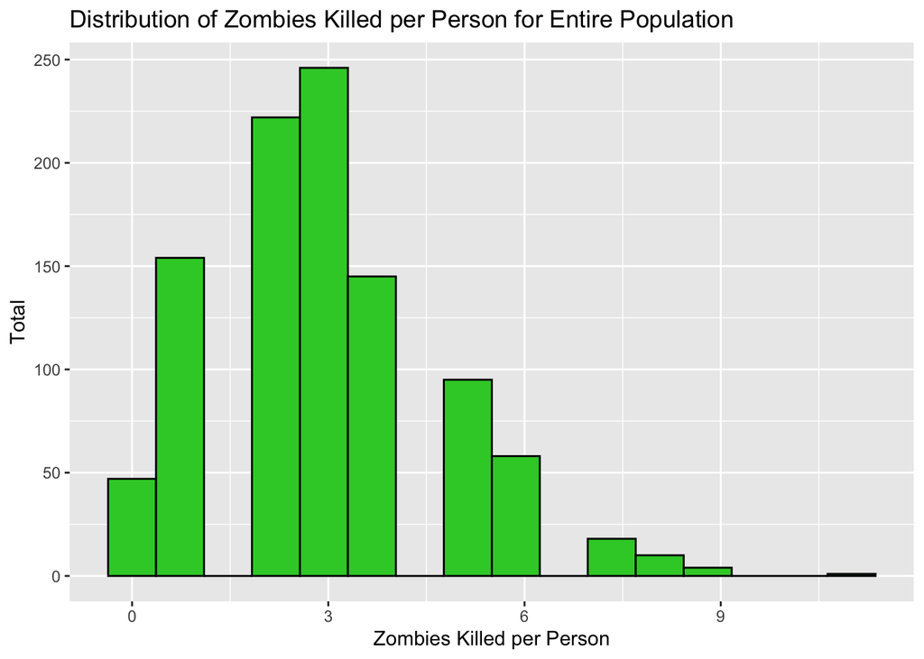

```r
zombies_killedHist<- ggplot(z, aes(x = zombies_killed)) +
  geom_histogram(color = "black", fill = "lime green", bins = 16) +
  ggtitle("Distribution of Zombies Killed per Person for Entire Population") +
  ylab("Total") +
  xlab("Zombies Killed per Person")
zombies_killedHist
```

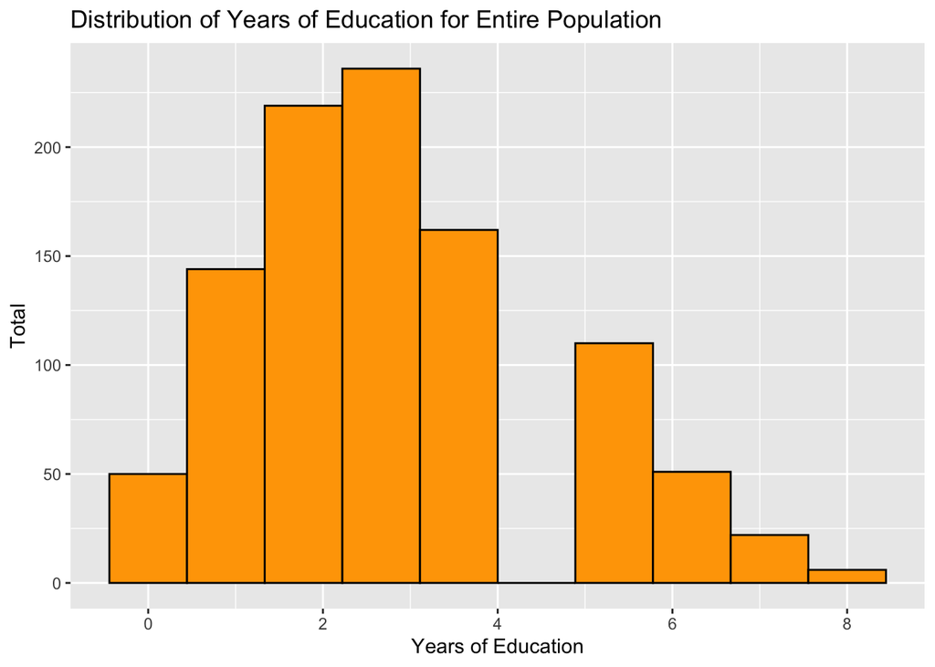

```r
years_of_educationHist<- ggplot(z, aes(x = years_of_education)) +
  geom_histogram(color = "black", fill = "orange", bins = 10) +
  ggtitle("Distribution of Years of Education for Entire Population") +
  ylab("Total") +
  xlab("Years of Education")
years_of_educationHist
```

#Here I create Q-Q plots of each quiantitative variable variables =(height, weight, age, number of zombies_killed, and years_of_education

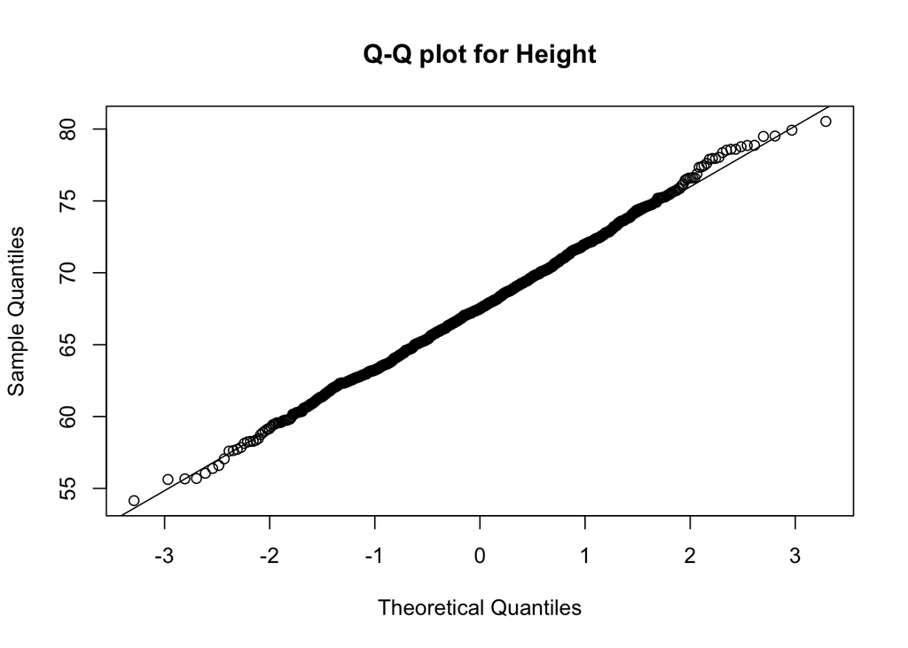

```r
qqnorm(z$height, main = "Q-Q plot for Height")
qqline(z$height)
```

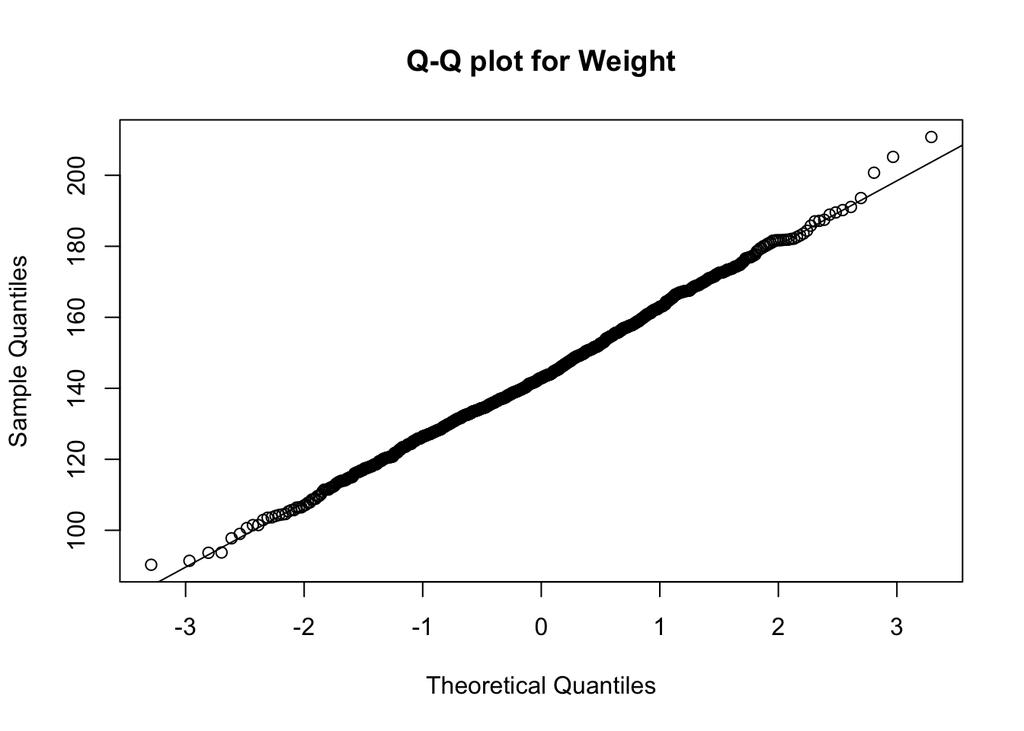

```r
qqnorm(z$weight, main = "Q-Q plot for Weight")
qqline(z$weight)
```

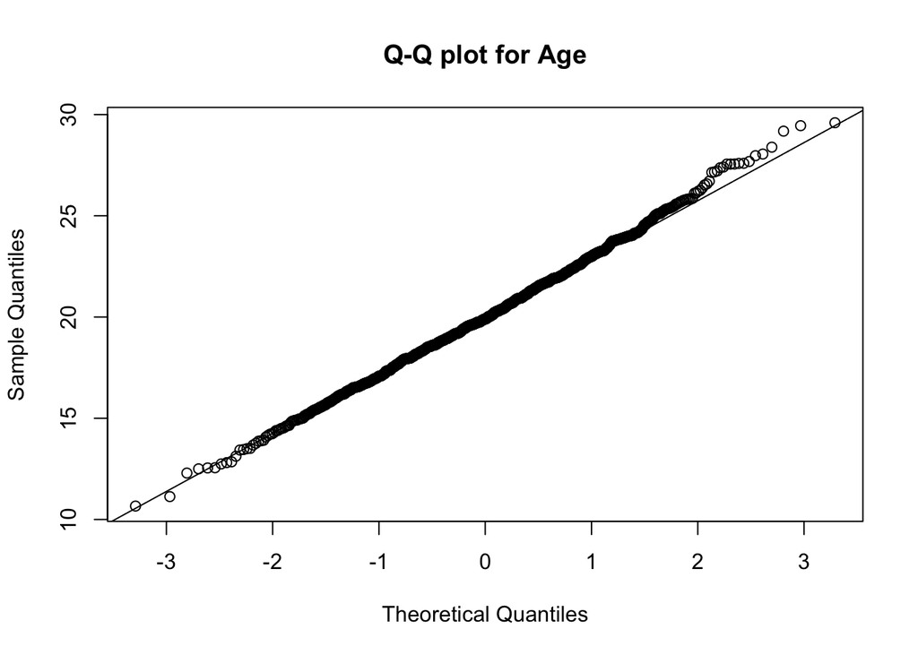

```r
qqnorm(z$age, main = "Q-Q plot for Age")
qqline(z$age)
```

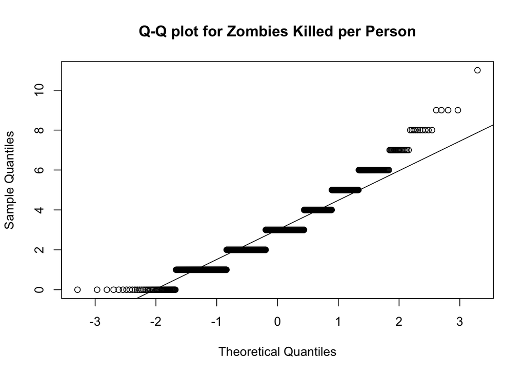

```r
qqnorm(z$zombies_killed, main = "Q-Q plot for Zombies Killed per Person")
qqline(z$zombies_killed)
```

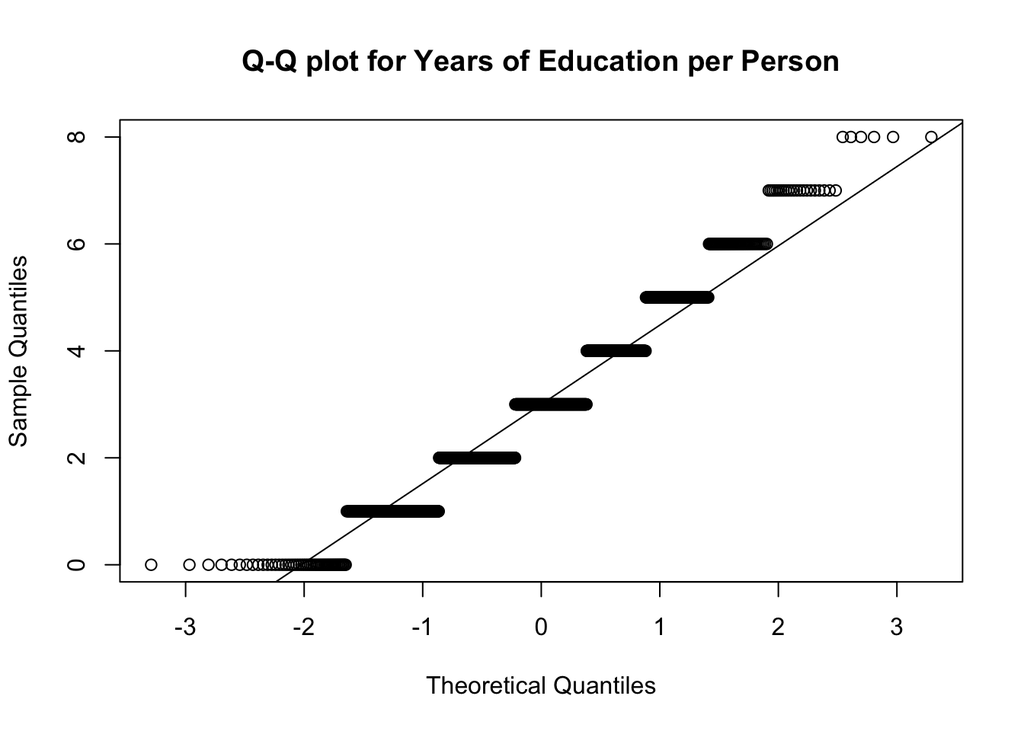

```r
qqnorm(z$years_of_education, main = "Q-Q plot for Years of Education per Person")
qqline(z$years_of_education)
```